# Data Visualization using R

## the potential

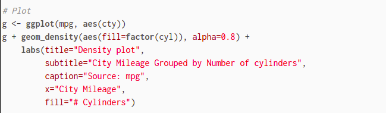

## the potential

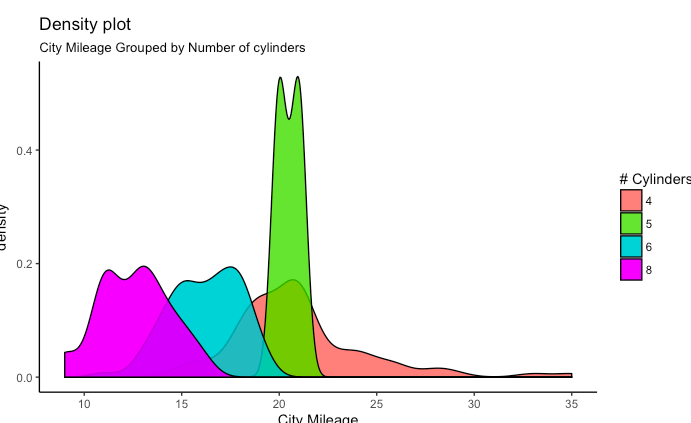

## the potential

[figure not shown]

## First chart (Joe)

## First chart (Joe)

```
## # A tibble: 6 x 6
##   country     continent  year lifeExp      pop gdpPercap
##   <fct>       <fct>     <int>   <dbl>    <int>     <dbl>
## 1 Afghanistan Asia       1952    28.8  8425333      779.
## 2 Afghanistan Asia       1957    30.3  9240934      821.
## 3 Afghanistan Asia       1962    32.0 10267083      853.
## 4 Afghanistan Asia       1967    34.0 11537966      836.
## 5 Afghanistan Asia       1972    36.1 13079460      740.
## 6 Afghanistan Asia       1977    38.4 14880372      786.
```

## First chart (Joe)

[figure not shown]

## First chart (Joe)

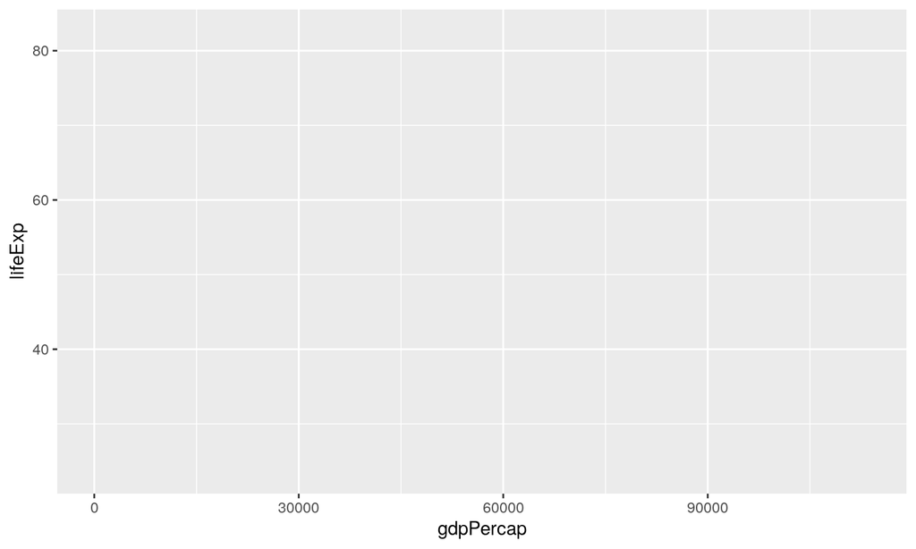

## First chart (Joe)

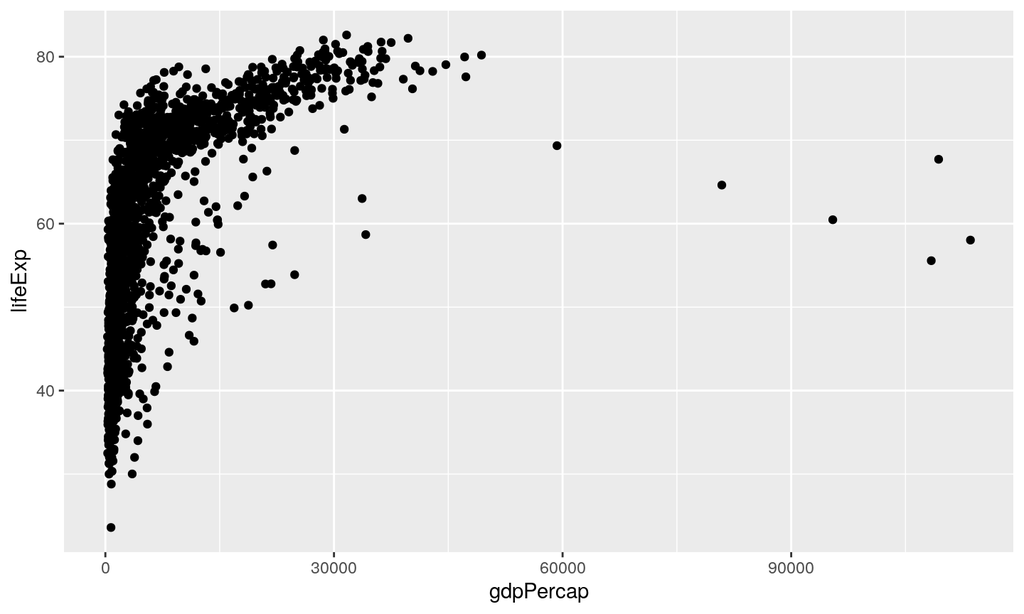

## Preparing the data

## Preparing the data

### Importing data from files (Arsenio)

Set the working directory (`setwd('path_to_a_folder')`)

- It’s a folder in your computer where `R` search for and save files by default

## Preparing the data

### Importing data from files (Arsenio)

Different packages/functions to import data from different file formats

## Preparing the data

### Importing data from files (Arsenio)

Swiss-army knife for data import/export: `rio`

## Preparing the data

### Example study

Suppose we have three datasets from a study:

- `recruitment.xlsx` – data collected during the participant recruitment
- `clinic_visit1.xlsx` – data from the first clinic visit
- `clinic_visit2.xlsx` – data from the second clinic visit, has the same variables as `clinic_visit1.xlsx`

## Preparing the data

### Creating new variables

- Create age at recruitment in days (`age_d`) and in years (`age_y`) variables in the `rec`data frame
- Check the tidyverse’s `lubridate` package for more advanced date/time manipulation

## Preparing the data

### Joining data frames vertically (appending)

- `cv1` and `cv2` have the same variables (columns), let’s combine them vertically

## Preparing the data

### Joining data frames horizontally (merging)

- Now that we have all visits’ data in one row per participant, we would like to joint them with the corresponding participant data from the recruitment (`rec`)

## Preparing the data

### Recode categorical variables

- The variable `sex` is stored as numeric (1 and 2), where *1=Female* and *2=Male*
- `marital_status` is stored as *sing* (Single), *marr* (Married), *divo* (Divorced) and *wido* (Widowed)

## Preparing the data

### Subsetting data – rows (observations)

- `dataframe_name[row_selection,]`
- `row_selection` can be a
  - vector of row numbers
    - `rcv[2,]` returns the 2<sup>nd</sup> row
    - `rcv[c(1,3,7),]` returns 1<sup>st</sup>, 3<sup>rd</sup> and 7<sup>th</sup> rows
  - logical vector (TRUE/FALSE) whose length is equal to the total number of rows of the data frame
    - returns rows in positions where the vector has the value `TRUE`
    - it is often given as a logical condition involving the operators `<` (less than), `<=` (less than or equal to), `>`, `>=`, `==` (equal to), `!=` (not equal), `!` (not), `|` (or), `&` (and), `is.na()` (returns true for missing values, `NA`)

## Preparing the data

### Subsetting data – columns (variables)

- `dataframe_name[,column_selection]`
- `colu_selection` can be a
  - vector of column numbers to keep or drop
    - `rcv[,c(1,3,5)]` keeps the 1<sup>st</sup>, 3<sup>rd</sup> and 5<sup>th</sup> columns
    - `rcv[,-c(1,3,5)]` drops the 1<sup>st</sup>, 3<sup>rd</sup> and 5<sup>th</sup> columns
  - vector of column names to keep
    - `rcv[,c(“subjectid”, “sex”, “marital_status”)]

## Preparing the data

### Saving data frame to a file

- You can easily save your R data frames in different file formats using the `rio` package

## Preparing the data

### Tranforming data (Joe)

(Interactive activity)

## Preparing the data

### Tranforming data (Joe)

## Preparing the data

### Tranforming data (Joe)

- Create an object called `gmx`. This will be `gm`, but we will `filter` to include only the most recent year (2007).

## Preparing the data

### Tranforming data (Joe)

- Create an object called `gmx`. This will be `gm`, but we will `filter` to include only the most recent year (2007).

## Preparing the data

### Tranforming data (Joe)

- Create an object called `gmx`. This will be `gm`, but we will `filter` to include only the most recent year (2007).

## Preparing the data

### Tranforming data (Joe)

- Make an object called `ncountries`. To do this, group the data by continent and `tally` the number of countries

## Preparing the data

### Tranforming data (Joe)

- Make an object called `ncountries`. To do this, group the data by continent and `tally` the number of countries

## Preparing the data

### Tranforming data (Joe)

- Arrange `ncountries` from lowest to highest

## Preparing the data

### Tranforming data (Joe)

- Arrange `ncountries` from lowest to highest

## Preparing the data

### Tranforming data (Joe)

- Make a plot of the continents (x-axis) and the number of countries (y-axis)

## Preparing the data

### Tranforming data (Joe)

- Make a plot of the continents (x-axis) and the number of countries (y-axis)

[figure not shown]

## Preparing the data

### Tranforming data (Joe)

- Make a plot of the continents (x-axis) and the number of countries (y-axis)

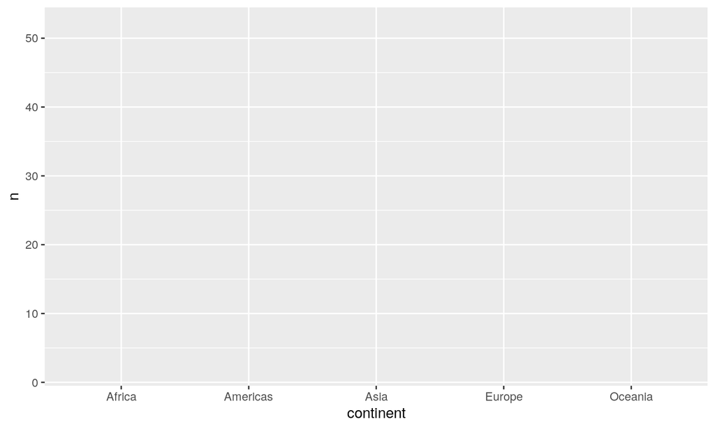

## Preparing the data

### Tranforming data (Joe)

- Make a plot of the continents (x-axis) and the number of countries (y-axis)

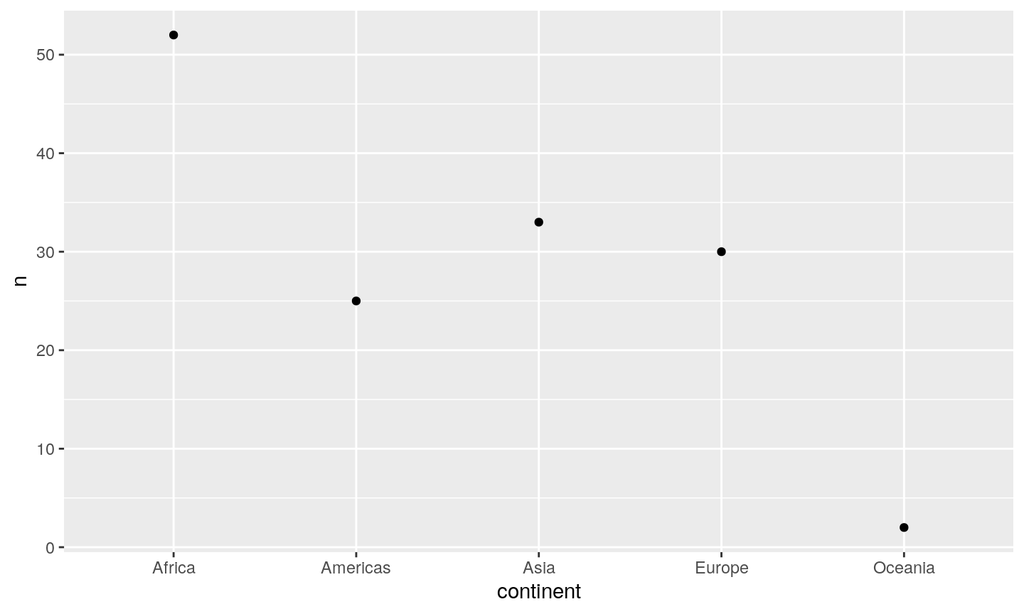

## Preparing the data

### Tranforming data (Joe)

- Let’s create an object called `moz`. This will be the gapminder data, but just for Mozambique.

## Preparing the data

### Tranforming data (Joe)

- Let’s create an object called `moz`. This will be the gapminder data, but just for Mozambique.

## Preparing the data

### Tranforming data (Joe)

- Plot GDP per capita over time

## Preparing the data

### Tranforming data (Joe)

- Plot life expectancy over time

## Preparing the data

### Tranforming data (Joe)

- Plot the association between gdpPercap and life expectancy

## Preparing the data

### Tranforming data (Joe)

- Plot the association between gdpPercap and life expectancy

## Preparing the data

### Tranforming data (Joe)

- Take the gapminder data, keep only 2007 data, group by continent, and get the maximum and minimum life expectancy for each continent

## Preparing the data

### Tranforming data (Joe)

- Take the gapminder data, keep only 2007 data, group by continent, `mutate` a new variable with the average GDP for that continent, `mutate` another variable with the difference between each country and its continent’s average GDP

## Discussion and activities

- How else can we visualize the `gapminder` data?